# outbreak.info R package

August 11, 2020

```r
knitr::kable(printAPIFields())
```

| API Field | Documentation |
| --- | --- |
| admin_level | Administrative level (World Bank regions = -1, countries = 0, states/provinces = 1, metropolitan areas = 1.5, counties = 2) |
| cbsa | Metropolitan area FIPS code |
| confirmed | Total number of confirmed COVID-19 cases |
| confirmed_doublingRate | Doubling rate of confirmed COVID-19 cases (number of days for COVID-19 cases to double) |
| confirmed_firstDate | Date of first confirmed COVID-19 case |
| confirmed_newToday | T if new COVID-19 cases reported, F if none |
| confirmed_numIncrease | Number of new confirmed COVID-19 cases |
| confirmed_pctIncrease | Percent increase in confirmed COVID-19 cases |
| confirmed_per_100k | Total number of confirmed COVID-19 cases per 100,000 persons |
| confirmed_rolling | Weekly rolling average of new confirmed COVID-19 cases |
| confirmed_rolling_14days_ago | Weekly rolling average of new confirmed COVID-19 cases 14 days prior |
| confirmed_rolling_14days_ago_diff | Difference between a weekly rolling average of new confirmed COVID-19 cases and the weekly rolling average of new confirmed COVID-19 cases 14 days prior |
| confirmed_rolling_per_100k | Weekly rolling average of new confirmed COVID-19 cases per 100,000 persons |
| country_gdp_per_capita | Country GDP per capita |
| country_iso3 | Country ISO3 |
| country_name | Country name |
| country_population | Total population of country |
| date | Date |
| daysSince100Cases | Days since 100 new confirmed cases of COVID-19 reported |
| daysSince10Deaths | Days since 10 new deaths due to COVID-19 reported |
| daysSince50Deaths | Days since 50 new deaths due to COVID-19 reported |
| dead | Total number of deaths due to COVID-19 |
| dead_doublingRate | Doubling rate of deaths due to COVID-19 (number of days for deaths due to COVID-19 to double) |
| dead_firstDate | Date of first death due to COVID-19 |
| dead_newToday | T if new deaths due to COVID-19 reported, F if none |
| dead_numIncrease | Number of new deaths due to COVID-19 |
| dead_pctIncrease | Percent increase in deaths due to COVID-19 |
| dead_per_100k | Total number of deaths due to COVID-19 per 100,000 persons |
| dead_rolling | Weekly rolling average of new deaths due to COVID-19 |
| dead_rolling_14days_ago | Weekly rolling average of new deaths due to COVID-19 14 days prior |
| dead_rolling_14days_ago_diff | Difference between a weekly rolling average of new deaths due to COVID-19 and the weekly rolling average of new deaths due to COVID-19 14 days prior |
| dead_rolling_per_100k | Weekly rolling average of new deaths due to COVID-19 per 100,000 persons |
| first_dead-first_confirmed | Number of days between first confirmed case of COVID-19 and first death due to COVID-19 |
| gdp_last_updated | Year that GDP was last updated |
| gdp_per_capita | GDP per capita |
| iso3 | ISO3 code |
| lat | Latitude |
| location_id | Location code |
| long | Longitude |
| mostRecent | T for most recent row of data, F for all others |
| name | Location name |
| num_subnational | Number of administrative divisions |
| population | Total population |
| recovered | Total number of recovered cases of COVID-19 |
| recovered_doublingRate | Doubling rate of recovered cases of COVID-19 (number of days for recovered cases of COVID-19 to double) |
| recovered_firstDate | Date of first recovered case of COVID-19 |
| recovered_newToday | T if new recovered COVID-19 cases reported, F if none |
| recovered_numIncrease | Number of new recovered cases of COVID-19 |
| recovered_pctIncrease | Percent increase in recovered cases of COVID-19 |
| recovered_per_100k | Total number of recovered cases of COVID-19 per 100,000 persons |
| recovered_rolling | Weekly rolling average of new recovered cases of COVID-19 |
| recovered_rolling_14days_ago | Weekly rolling average of new recovered cases of COVID-19 14 days prior |
| recovered_rolling_14days_ago_diff | Difference between a weekly rolling average of new recovered cases of COVID-19 and the weekly rolling average of recovered cases of COVID-19 14 days prior |
| recovered_rolling_per_100k | Weekly rolling average of new recovered cases of COVID-19 per 100,000 persons |
| state_iso3 | State ISO3 code |
| state_name | State name |
| sub_parts | County name, county FIPS code, state name |
| testing_* | Documentation found at [The COVID Tracking Project](https://covidtracking.com/data-definitions) |
| wb_region | World Bank region |

#### **getISO3**

**Description:**

Get ISO3 codes for World Bank regions, countries, states/provinces, metropolitan areas, and/or counties.

**Usage:**

```r
getISO3(locations_to_search)
```

**Arguments:**

locations_to_search: a `vector` or `list` of location (World Bank region, country, state/province, metropolitan area, county) name(s)

**Example:**

```r
iso3=getISO3(c("Texas", "Brazil", "San Diego County"))
print(iso3)
```

```
## [1] "USA_US-TX"       "BRA"             "USA_US-CA_06073"
```

#### **searchLocations**

**Description:**

Get exact spelling of locations at the same administrative level.

**Usage:**

```r
searchLocations(locations_to_search, admin_level)
```

**Arguments:**

locations_to_search: a `vector` or `list` of location (World Bank region, country, state/province, metropolitan area, county) name(s) at the same administrative level

admin_level: an `integer` representing an administrative level (World Bank regions = -1, countries = 0, states/provinces = 1, metropolitan areas = 1.5, counties = 2)

**Example:**

```r
names=searchLocations(c("California", "Florida", "Texas"), admin_level=1)
print(names)
```

```
## [1] "California" "Florida"    "Texas"
```

#### **getLocationData**

**Description:**

Retrieve a `dataframe` of up-to-date COVID-19 data from [outbreak.info](https://outbreak.info/) for one or more World Bank regions, countries, states/provinces, metropolitan areas, and/or counties.

**Usage:**

```r
getLocationData(location_names)
```

**Arguments:**

location_names: a `vector` or `list` of location (World Bank region, country, state/province, metropolitan area, county) name(s)

**Example:**

```r
df=getLocationData(c("Texas", "Brazil", "San Diego County"))
df[!duplicated(df$name), c("name", "date", "confirmed")]
```

```
##                name       date confirmed
## 1            Brazil 2020-03-09        25
## 37 San Diego County 2020-02-14         1
## 87            Texas 2020-02-16         2
```

#### **getAdmn2ByState**

**Description:**

Retrieve a `dataframe` of up-to-date COVID-19 data from [outbreak.info](https://outbreak.info/) for all counties in given state(s).

**Usage:**

```r
getAdmn2ByState(states)
```

**Arguments:**

states: a `vector` or `list` of state names

**Example:**

```r
ca_df=getAdmn2ByState("California")
length(unique(ca_df$name))
```

```
## [1] 58
```

#### **getAdmn2ByCountry**

**Description:**

Retrieve a `dataframe` of up-to-date COVID-19 data from [outbreak.info](https://outbreak.info/) for all counties in the United States of America.

**Usage:**

```r
getAdmn2ByCountry()
```

**Arguments:**

none

**Example:**

```r
county_df=getAdmn2ByCountry()
length(unique(county_df$name))
```

```
## [1] 1942
```

#### **getMetroByCountry**

**Description:**

Retrieve a `dataframe` of up-to-date COVID-19 data from [outbreak.info](https://outbreak.info/) for all metropolitan areas in the United States of America.

**Usage:**

```r
getMetroByCountry()
```

**Arguments:**

none

**Example:**

```r
metro_df=getMetroByCountry()
length(unique(metro_df$name))
```

```
## [1] 923
```

#### **getAdmn1ByCountry**

**Description:**

Retrieve a `dataframe` of up-to-date COVID-19 data from [outbreak.info](https://outbreak.info/) for all states/provinces in one or more countries.

**Usage:**

```r
getAdmn1ByCountry(countries)
```

**Arguments:**

countries: a `vector` or `list` of country names

**Example:**

```r
state_df=getAdmn1ByCountry("India")
print(unique(state_df$name))
```

```
##  [1] "Andaman and Nicobar" "Andhra Pradesh"      "Arunachal Pradesh"
##  [4] "Assam"               "Bihar"               "Chandigarh"
##  [7] "Chhattisgarh"        "Delhi"               "Goa"
## [10] "Gujarat"             "Himachal Pradesh"    "Haryana"
## [13] "Jharkhand"           "Jammu and Kashmir"   "Karnataka"
## [16] "Kerala"              "Maharashtra"         "Meghalaya"
## [19] "Manipur"             "Madhya Pradesh"      "Mizoram"
## [22] "Nagaland"            "Orissa"              "Punjab"
## [25] "Rajasthan"           "Sikkim"              "Tamil Nadu"
## [28] "Tripura"             "Uttar Pradesh"       "Uttaranchal"
## [31] "West Bengal"
```

#### **getCountryByRegion**

**Description:**

Retrieve a `dataframe` of up-to-date COVID-19 data from [outbreak.info](https://outbreak.info/) for all countries in one or more World Bank regions.

**Usage:**

```r
getCountryByRegion(wb_regions)
```

**Arguments:**

wb_regions: a `vector` or `list` of World Bank region names

**Example:**

```r
region_df=getCountryByRegion("South Asia")
print(unique(region_df$name))
```

```
## [1] "Afghanistan" "Bhutan"      "Bangladesh"  "Sri Lanka"   "Maldives"
## [6] "India"       "Pakistan"    "Nepal"
```

#### **plotCovid**

**Description:**

Plot a metric of interest using up-to-date COVID-19 data using data from [outbreak.info](https://outbreak.info/) for location(s) of interest (World Bank region, country, state/province, metropolitan area, county)

**Usage:**

```r
plotCovid(locations, key)
```

**Arguments:**

location: a `vector` or `list` of location name(s)

key: metric to plot

**Example:**

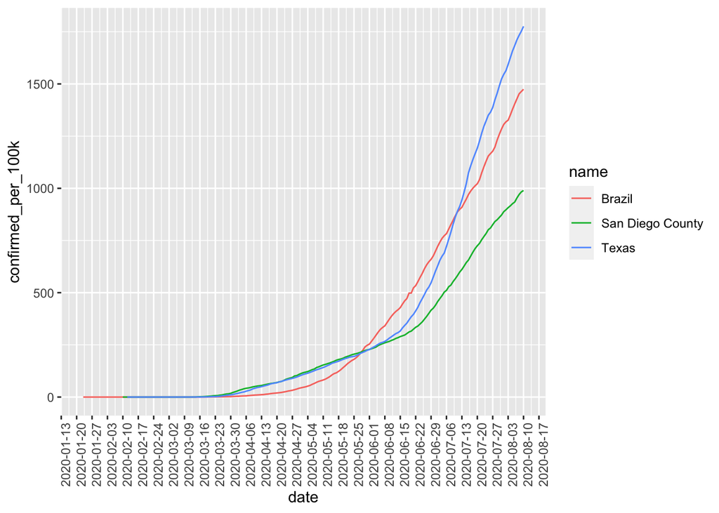

```r
p=plotCovid(c("Texas", "Brazil", "San Diego County"), "confirmed_per_100k")
show(p)
```